# Understanding the Institutional Complex of Energy-Related Cooperative Climate Initiatives

Yichen Shen

2023-12-22

# Theoretical Framework

How can we understand the stage of complexity? What drives the institutional complex, and how can we identify these drivers? Pursuing answers to these questions, [Chelminski and others (2022)](https://brill.com/view/journals/gg/28/4/article-p587_6.xml?language=en&ebody=abstract%2Fexcerpt) conducted a social network analysis on 11 multilateral institutions and 33 initiatives to understand the drivers of the clean energy regime complex from 1990 to 2014. This analysis included factors such as state preferences, the rise of transnational actors, international organizations (IOs)’ orchestration, and recognition and legitimation based on the structuring effects of networked governance itself.

Building on this study, I constructed an undirected, two-mode network with 10 different types of actors and 49 energy-related initiatives from the [Climate Initiatives Platform](https://climateinitiativesplatform.org/index.php/Welcome) to comprehend what shapes the institutional complex of energy-related climate initiatives. Specifically, this study proposes 5 hypotheses.

## Hypothesis

1. **Actor’s Interests**

   H1: States, due to various political divergences and power differentials, tend to join more initiatives than other types of actors.

   H2: The rise of transnational private and public governance, and the power of transnational actors, specifically including subnational governmental entities and private companies, leads to increased participation and the formation of more initiatives.
2. **Role of Homophily**

   H3: Actors involved in initiatives with certain types of actors are also likely to be involved in initiatives with similar types of actors. This trend could be even more visible in initiatives with IOs as lead actors, [given their role in orchestrating partnerships with non-state actors](https://doi.org/10.1017/9781316694015).

   H4: Initiatives that feature certain types of actors are likely to attract similar types of actors.
3. **Network Structure**

   H5: The relationship between actors and initiatives is formed through clustering.

# Data Overview and Visualization

The network below is an undirected, two-mode network, indicating the ties between different types of actors and various initiatives. Nodes represent actors and initiatives, differentiated by color, with their size reflecting eigenvector centrality — a measure of influence considering not just the number of direct ties but also the importance of connected nodes. Edges illustrate actors’ participation in those initiatives, with their thickness denoting the logged weight of ties, which was done to address the skewed distribution of raw tie strengths and enhancing visibility. The visual suggests a few highly central actors (e.g, companies, cities, and states) and initiatives (e.g., NZCBC) that may act as pivotal points for climate-related cooperation, revealing the network’s core structure and potential channels for information flow and influence.

Type of actors: Companies, Business Orgnizatins (BOs), Research and Educational Organizations (REOs), International Non-Governmental Orgnizations (INGOs), States, National Governmental Agencies (NGAs), Regions, Cities, IGOs, FIs.

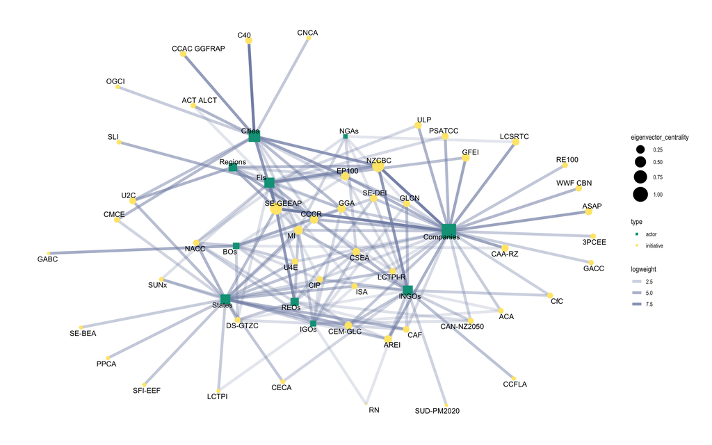

# Modelling

To address the outlined hypotheses concerning actor interests, homophily, and network structure in the realm of climate action networks, this study will utilize an [exponential family random graph model (ERGM) on a two-mode network](https://inarwhal.github.io/NetworkAnalysisR-book/ch13-Two-mode-Network-Models-ERGM-STERGM-R.html#ergm-on-a-two-mode-network). Each hypothesis corresponds to specific ERGM terms. First, regarding different actors’ participation in initiatives (H1 and H2), b1factor() term will be used to include all types of actors and then select the ones has statistical siginificance to participate in more initiatives than others. Then to assess the role of homophily (H3 and H4), b1/2nodematch() term will be used respectively to analyze the homophily effect within each node group. Further, the gwb2nsp() term will be employed to see if any clustering effects exist in the formation of relationship between type of actors and various initiatives (H5).

## Results

The ERGM shows with high confidence that States and INGOs are more engaged in climate initiatives, confirming that specific actor types are more active, as hypothesized. However, the reduced participation of NGAs, Regions, and REOs challenges the expected widespread engagement. While there’s evidence of homophily, the negative clustering effect suggests a more complex interaction pattern, and the lack of data variation prevents a clear conclusion on the influence of actor types across initiatives.

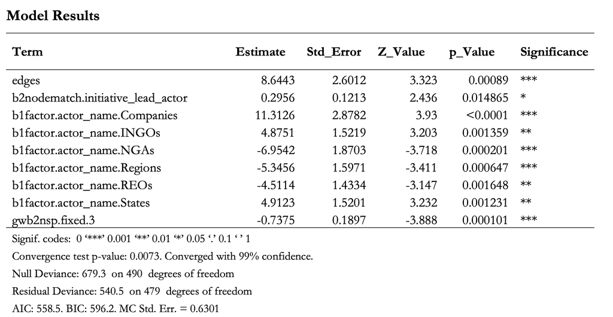

# Markov Chain Monte Carlo (MCMC) Diagnostics

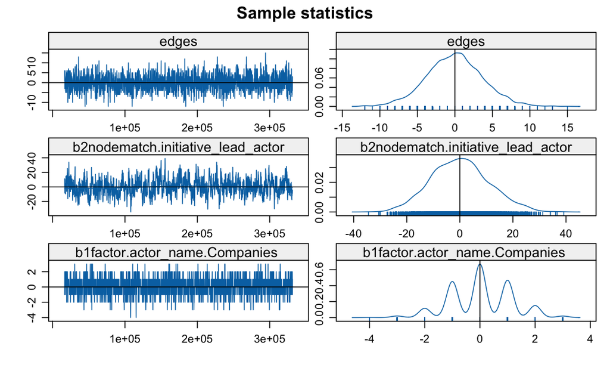

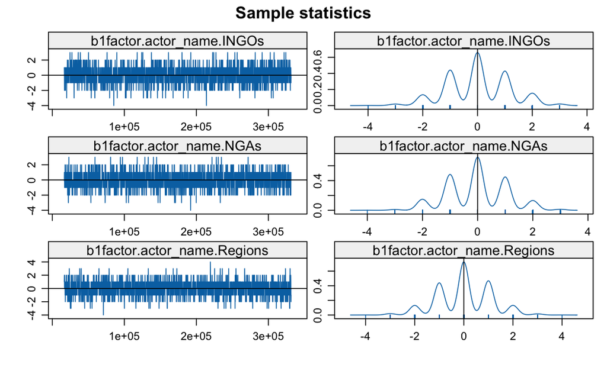

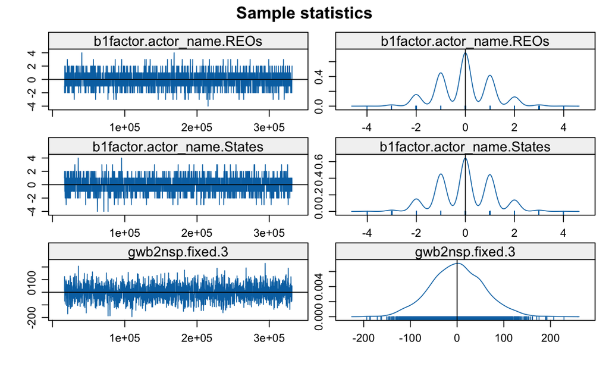

# Goodness of Fit

As showcased in the graphs below, The GOF results generally indicate a good fit, with most degree distributions in both partitions showing no significant difference between the observed data and model predictions. However, certain degree values in bipartition 2 (1-4) show discrepancies, indicating potential areas for model improvement.

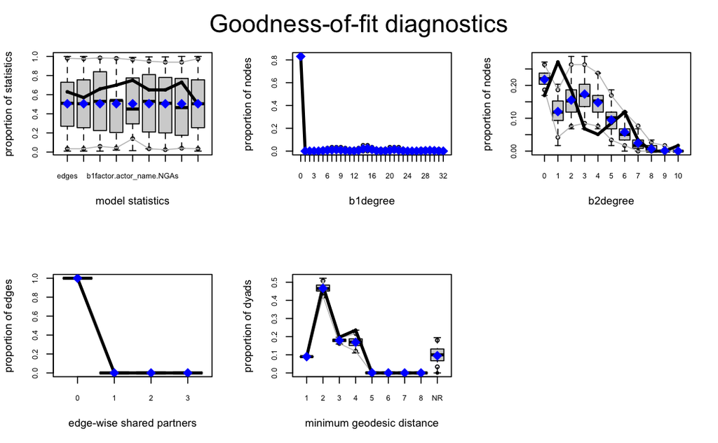

# Conclusion